# List

```python
[x**2 for x in range(10)]
```

```
[0, 1, 4, 9, 16, 25, 36, 49, 64, 81]
```

```python
l1 = [1,2,3]
l2 = ['a','b','c']
pair = [[i,j] for i in l1 for j in l2]
print(pair)
```

```
[[1, 'a'], [1, 'b'], [1, 'c'], [2, 'a'], [2, 'b'], [2, 'c'], [3, 'a'], [3, 'b'], [3, 'c']]
```

```python
words = ['hello','world','python','list']
length =[ len(word) for word in words]
print(length)
```

```
[5, 5, 6, 4]
```

```python
list((1,2,3,4))
```

```
[1, 2, 3, 4]
```

```python
nums = (1,2,3,45,1,2,45,5,2)
nums.count(1) # count the no of ones in nums
```

```
2
```

```python
mixed_tuple = (1,'hello',True)
print(mixed_tuple)
```

```
(1, 'hello', True)
```

## packing and unpacking of tuples

```python
packed_tuple = 1,'hello',3.14
print(type(packed_tuple))
```

```
<class 'tuple'>
```

```python
a,b,c = packed_tuple
print(a)
print(b)
print(c)
```

```
1
hello
3.14
```

```python
nested_tuple = ((1,2,3),('a','b','c'),(True,False))
```

```python
for sub_tuple in nested_tuple:
    #print(sub_tuple)
    for item in sub_tuple:
        print(item,end=' ')
    print()
```

```
1 2 3
a b c
True False
```

# Set

```python
empty_set = set()
```

```python
empty_set.add(4)
```

```python
print(empty_set)
```

```
{4}
```

```python
empty_set.remove(4)
```

```python
print(empty_set)
```

```
set()
```

```python
set1 = {1,2,3}
set2 = {2,4,5}
print(set1.issubset(set2))
print(set1.issuperset(set2))
```

```
False
False
```

```python
print('hello world')
```

```
hello world
```

```python
hello = set()
```

```python
print(type(hello))
```

```
<class 'set'>
```

# Dictionary

```python
dict = {'name':'Achyuth','age':22}
for value in dict.values():
    print(value)
```

```
Achyuth
22
```

```python
dicts = {x**2 for x in range(10)}
print(dicts)
```

```
{0, 1, 64, 4, 36, 9, 16, 49, 81, 25}
```

```python
print(dicts)
```

```
{0, 1, 64, 4, 36, 9, 16, 49, 81, 25}
```

```python
dictonery = {'ak',34,True,'Hello'}
```

```python
print(dictonery)
```

```
{'ak', 34, 'Hello', True}
```

#### october 15 - 2024

# Functions

### 1.Temperature Conversion

```python
def convert_temp(temp,unit):
    """ This function converts temp b/w celsius and fahrenheit"""
    if unit == 'C':
        return temp*9/5 + 32 # celsius to fahrenheit
    elif unit == 'F':
        return (temp-32)*5/9 # fahrenheit to celsius
    else:
        return None
```

```python
print(convert_temp(32,'C')) # celsius to fahrenheit
print(convert_temp(77,'F')) # fahrenheit to celsius
```

```
89.6
25.0
```

### 2.Password Strength Checker

```python
def check_password(password):
    """The function checks the password is strong or not """
    if len(password)<8:
        return False
    if not any(char.isdigit() for char in password ):
         return False
    if not any(char.islower() for char in password):
         return False
    if not any (char.isupper() for char in password):
         return False
    if not any (char in '!@#$%^&*()_+' for char in password):
        return False
    else:
        print('password is strong')
```

```python
check_password('ak@achyuth')
```

```
False
```

```python
check_password('Ak@achyuth_47')
```

```
password is strong
```

### 3. Calculate total cost of items in a shopping cart

```python
def cart_item(cart):
    total_cost =0
    for item in cart:
        total_cost+= item['price']*item['quantity']
    return total_cost

cart= [
    {'name':'Apple','price':10,'quantity':5},
    {'name':'banana','price':15,'quantity':3},
    {'name':'Bat','price':359,'quantity':1},
    {'name':'Shirts','price':100,'quantity':2},
]
# calling the function
total_cost =cart_item(cart)
print(total_cost)
```

```
654
```

### 4. Check the string is palindrome

```python
def palindrome(string):
    if string == string[::-1]:
        print('string is plaindrome')
    else:
        print('Not a palindrome')
```

```python
palindrome('RACECAR')
```

```
string is plaindrome
```

```python
palindrome('achyuth')
```

```
Not a palindrome
```

### 5. Factorial of a Number using recursion

```python
def factorial(n):
    if n == 0:
        return 1
    else:
        return n * factorial(n-1)
```

```python
factorial(3)
```

```
6
```

### 6. Function to read a file and count the frequency of each word

```python
def count_word_frequency(file_path):
    word_count = {}
    with open(file_path,'r') as file :
        for line in file:
            words = line.split()
            for word in words:
                word = word.lower().strip(',.!@#$%^&*()_+')
                word_count[word] = word_count.get(word,0)+1
    return word_count

file_path = 'sample.txt'
word_frequency = count_word_frequency(file_path)
print(word_frequency)
```

```
{'my': 1, 'self': 1, 'danda': 1, 'achyuth': 1, 'kumar': 1, 'reddy': 1, 'i': 1, 'am': 1, 'working': 1, 'as': 1, 'international': 1, 'data': 1, 'analyst': 1}
```

### 7.validate email address

```python
import re

def is_valid_email(email):
     pattern = r'^[a-zA-Z0-9_,+-]+@[a-zA-Z0-9-]+\.[a-zA-Z0-9-.]+$'
     return re.match(pattern,email) is not None

    # calling the function
print(is_valid_email('achyuthkumar@gmail.com'))
print(is_valid_email(' qqsxasv-email'))
```

```
True
False
```

#### october 16 - 2024

## Map

```python
condition = list(map(lambda x: x > 5 and x % 2 == 0, [1, 3, 4, 6, 8, 7, 9, 5]))
print(condition)
```

```
[False, False, False, True, True, False, False, False]
```

### Map functions give output as True or False

## Filter

```python
cond = list(filter(lambda x: x > 5 and x % 2 == 0, [1, 3, 4, 6, 8, 7, 9, 5]))
print(cond)
```

```
[6, 8]
```

```python
words = ['APPLE','john','Achyuth']
filter_words = list(filter(str.upper,words))
print(filter_words)
```

```
['APPLE', 'john', 'Achyuth']
```

#### There is a misunderstanding regarding the filter() function. The filter() function is used to filter items from an iterable based on whether a condition is True or False. The first argument to filter() should be a function that returns (True) or (False) for each item in the iterable, but str.upper is just a method for converting strings to uppercase, not a boolean function.

```python
#Correct one
```

```python
words = ['APPLE', 'john', 'Achyuth']
filter_words = list(filter(lambda word: word.isupper(), words))
print(filter_words)
```

```
['APPLE']
```

### Filter function displays output

### To display output for Map and filter must and should they need to convert to list

```python
print('----------------------------------------------------------------')
```

[output not shown]

## Lambda

#### This function can have any number of arguments but only one expression, which is evaluated and returned.

## syntax = lambda arguments : expression

```python
# example
x = lambda a : a + 10
print(x(5))
```

```
15
```

```python
la = lambda x,y,z : x>y<z
print(la(6,3,4))   # x >y 6>3 , y<z 3<4 is True
```

```
True
```

```python
la = lambda x,y,z : x+y+z and x*y*z
print(la(6,3,4))  # it takes multiplicaton
```

```
72
```

The issue is with the x + y + z and x *y* z expression inside the lambda function. Here's how it gets evaluated: x + y + z is computed first. It results in a value, let's say v1. v1 and x *y* z is then evaluated. The and operator returns the second operand (x *y* z) when the first one (v1) is a non-zero value (which is always the case for a valid sum of integers in this case). As a result, the sum (x + y + z) is essentially ignored, and only the product (x *y* z) will be returned.

```python
la = lambda x,y,z : x+y+z or x*y*z
print(la(6,3,4))  # it takes addition
```

```
13
```

```python
la = lambda x,y,z : x*y*z
print(la(6,3,4))
```

```
72
```

# Modules and packages

```python
import math
math.sqrt(16)
```

```
4.0
```

```python
from math import sqrt,pi
print(sqrt(16))
print(sqrt(25))
print(pi)
```

```
4.0
5.0
3.141592653589793
```

#### . Starting from Python 3.3, it's no longer required to include an **init**.py file, though it is still common practice to use one.

### **init**.py must have in package to called it as package for before python 3.3 versions

```python
# random
import random
val = random.randint(1,10)
var = random.choice(["Apple","banana","mango","biscuits"])
```

```python
print(val)
```

```
7
```

```python
print(var)
```

```
banana
```

```python
#### Standard libraries
#### Numpy,os,pandas,array,math,random
```

```python
import os
print(os.getcwd())
# to know the current working directory
```

```
C:\Users\admin\Downloads\Data Analytics\Python
```

```python
os.mkdir('udemy') # to create directory as udemy in present working directory
```

```python
import shutil
shutil.copyfile('sample.txt','designation.txt') # it creates dummy copy of sample.txt with name of file called designaton.txt
```

```
'designation.txt'
```

### json

```python
import json
data = {'name':'Achyuth','age':21}
json_str = json.dumps(data)
print(json_str)
print(type(json_str))
parsed_data = json.loads(json_str)
print(parsed_data)
print(type(parsed_data))
```

```
{"name": "Achyuth", "age": 21}
<class 'str'>
{'name': 'Achyuth', 'age': 21}
<class 'dict'>
```

### csv

```python
import csv
with open('example.csv',mode = 'w',newline = '') as file:
    writer = csv.writer(file)
    writer.writerow(['name','age'])
    writer.writerow(['Achyuth',21])
with open('example.csv',mode='r') as file:
    reader = csv.reader(file)
    for row in reader:
        print(row)
```

```
['name', 'age']
['Achyuth', '21']
```

### datetime

```python
from datetime import datetime,timedelta
now = datetime.now()
print(now)
yesterday = now-timedelta(days=1)
print(yesterday)
```

```
2024-10-16 19:48:47.281242
2024-10-15 19:48:47.281242
```

### Regular expression

```python
import re
pattern = r'\d+'
text = 'My self achyuth kumar and my roll no is 511 and my percentage is 80'
match = re.search(pattern,text)
print(match)
print(match.group())  # here at 511 its stops because the pattern match is found at 511 so it don't goes to 80
```

```
<re.Match object; span=(40, 43), match='511'>
511
```

# File handling

```python
# read afile
with open('sample.txt','r') as file:
    data = file.read()
    print(data)
```

```
hello my self Achyuth kumar

sorry to everyone for not responding

what happens to you
```

```python
# read line by line in file
with open('sample.txt','r') as file:
    for line in file:
        print(line.strip())
```

[output not shown]

```python
#over writing a file
with open('sample.txt','w') as file:
    file.write('hello present time is 8:15 in india\n')
    file.write('the past data was repalced or over written with this data')
```

```python
# reading over writing data
with open('sample.txt','r') as file:
    data = file.read()
    print(data)
```

```
hello present time is 8:15 in india
the past data was repalced or over written with this data
```

```python
#write a file without overwriting
with open('sample.txt','a') as file:
    file.write('here append operation takes place')
```

```python
with open('sample.txt','r') as file:
    data = file.read()
    print(data)
```

```
hello present time is 8:15 in india
the past data was repalced or over written with this datahere append operation takes place
```

```python
# writing a list of lines to a file
lines =['firts line\n','Second line\n','Third line\n']
with open('sample.txt','a') as file:
    file.writelines(lines)
```

```python
# to read the data
with open('sample.txt','r') as file:
    data = file.read()
    print(data)
```

```
hello present time is 8:15 in india
the past data was repalced or over written with this datahere append operation takes placefirts line
Second line
Third line
```

```python
# copy and pasting of data
with open('sample.txt','r') as source_file:
    content = source_file.read()
with open('designation.txt','w') as designation_file:
    designation_file.write(content)
```

```python
with open('designation.txt','r') as designation_file:
    print(designation_file.read())
```

```
hello present time is 8:15 in india
the past data was repalced or over written with this datahere append operation takes placefirts line
Second line
Third line
```

```python
# Read a text file and count the no of lines , words ,and characters.
def count_words_txt(file_path):
    with open(file_path,'r') as file:
        lines = file.readlines()
        line_count = len(lines)
        word_count = sum(len(line.split())for line in lines)
        char_count = sum(len(line) for line in lines)
    return lines,line_count,word_count,char_count
file_path = 'sample.txt'
lines = count_words_txt(file_path)
print(f'lines:{lines}')
```

```
lines:(['hello present time is 8:15 in india\n', 'the past data was repalced or over written with this datahere append operation takes placefirts line\n', 'Second line\n', 'Third line\n'], 4, 27, 160)
```

### W+ used for both reading and writing .If file does not exist file creates , *if file exists* the content is over written

```python
### Writing and then reading a file

with open('sample.txt','w+') as file:
    file.write("Hello world\n")
    file.write("This is a new line \n")

    ## Move the file cursor to the beginning
    file.seek(0)

    ## Read the content of the file
    content=file.read()
    print(content)
```

```
Hello world
This is a new line
```

```python
# Listing files and directories present in these directory
import os
items = os.listdir('.')
print(items)
```

```
['.ipynb_checkpoints', 'assignment_solutions.zip', 'designation.txt', 'dictionaries_assignment_solution.ipynb', 'example.csv', 'functionsassignmentsoln.ipynb', 'sample.bin', 'sample.txt', 'set_assignments_solution.zip', 'tuple_assignment_solution.zip', 'Udemy_Python.ipynb']
```

```python
# joining paths
dir_name = 'folder'
file_name = 'file.txt'
full_path = os.path.join(dir_name,file_name)
print(full_path)
```

```
folder\file.txt
```

```python
# joining paths
dir_name = 'folder'
file_name = 'file.txt'
full_path = os.path.join(os.getcwd(),dir_name,file_name)
print(full_path)
```

```
C:\Users\admin\Downloads\Data Analytics\Python\folder\file.txt
```

```python
path='example1.txt'
if os.path.exists(path):
    print(f"The path '{path}' exists")
else:
    print(f"The path '{path}' does not exists")
```

```
The path 'example1.txt' does not exists
```

```python
#Checking if a Path is a File or Directory
import os

path = 'example.txt'
if os.path.isfile(path):
    print(f"The path '{path}' is a file.")
elif os.path.isdir(path):
    print(f"The path '{path}' is a directory.")
else:
    print(f"The path '{path}' is neither a file nor a directory.")
```

```
The path 'example.txt' is neither a file nor a directory.
```

```python
# checking absolute path
relative_path = 'sample.txt'
abs_path = os.path.abspath(relative_path)
print(abs_path)
```

```
C:\Users\admin\Downloads\Data Analytics\Python\sample.txt
```

### October- 17 - 2024

# Exception handling

```python
a=b
```

```
---------------------------------------------------------------------------
NameError                                 Traceback (most recent call last)
Cell In[15], line 1
----> 1 a=b

NameError: name 'b' is not defined
```

```python
try:
    a=b
except:
    print('NameError')
```

```
NameError
```

```python
try:
    a=b
except NameError as ex:
    print(ex)
```

```
name 'b' is not defined
```

```python
value = 1/0
```

```
---------------------------------------------------------------------------
ZeroDivisionError                         Traceback (most recent call last)
Cell In[21], line 1
----> 1 value = 1/0

ZeroDivisionError: division by zero
```

```python
try:
    value=1/0
except ZeroDivisionError as zde:
    print(zde)
```

```
division by zero
```

```python
try:
    value=1/0
except ZeroDivisionError as zde:
    print('enter num in denominator > 0 to get the value')
```

```
enter num in denominator > 0 to get the value
```

```python
try:
    value=1/0
except Exception as zde:
    print(zde)
```

```
division by zero
```

#### Every exception was derived from base class *Exception*

```python
## try,except,else and finally
try:
    num = int(input("Enter a number: "))
    result = 10 / num
except ValueError:
    print("That's not a valid number!")
except ZeroDivisionError:
    print("You can't divide by zero!")
except Exception as ex:
    print(ex)
else:
    print(f"The result is {result}")
finally:
    print("Execution complete.")
```

```
The result is 2.5
Execution complete.
```

```python
### File handling and Exception HAndling

try:
    file=open('example1.txt','r')
    content=file.read()
    a=b
    print(content)

except FileNotFoundError:
    print("The file does not exists")
except Exception as ex:
    print(ex)

finally:
    if 'file' in locals() or not file.closed():
        file.close()
        print('file close')
```

```
The file does not exists
file close
```

Exceptions, on the other hand, occur during the execution of the program. *These errors are not detected by the parser but are raised during runtime* when a specific condition is encountered. Exceptions can be handled using try-except blocks

## How to handle exceptions

Exceptions in Python can be handled using the try, except, else, and finally blocks. The try block contains the code that might raise an exception, and the except block handles the exception

#### try: This block contains the code that might raise an exception. It is the part of the code that needs to be monitored for potential errors.

#### except: If an exception occurs in the try block, the corresponding except block is executed. It handles and catches the exception, preventing the program from crashing.

#### else: This block is executed if no exceptions occur in the try block. It contains code that should run only when there are no exceptions.

#### finally: This block always gets executed, whether an exception occurs or not. It is useful for releasing resources or cleaning up, ensuring that certain actions are taken regardless of the outcome.

```python
# exceptions can be raised explicitly using the raise statement.
def divide_numbers(num1, num2):
    if num2 == 0:
        raise ValueError("Cannot divide by zero.")
    else:
        return num1 / num2

try:
    result = divide_numbers(10, 0)

except ValueError as e:
    print("Error:", e)

else:
    print("Result:", result)
```

```
Error: Cannot divide by zero.
```

```python
#Q)Catching Multiple Exceptions in a Single Except Block:
# A)except (ZeroDivisionError, TypeError) as e:
```

### Creating a Custom Exception in Python:

#### In Python, you can create custom exceptions by defining a new class that inherits from the built-in Exception class or one of its subclasses. This allows you to raise and catch exceptions that are specific to your application or use case.

```python
class CustomError(Exception):
    def __init__(self, message="Custom error occurred"):
        self.message = message
        super().__init__(self.message)

def custom_function(value):
    try:
        if value < 0:
            raise CustomError("Negative value not allowed")

        # Perform some operations with the value
        result = 10 / value

    except CustomError as ce:
        print(f"CustomError: {ce}")

    else:
        print("No custom error occurred.")

    finally:
        print("Cleanup or finalization code here.")

# Example usage
custom_function(5)
custom_function(-2)
```

```
No custom error occurred.
Cleanup or finalization code here.
CustomError: Negative value not allowed
Cleanup or finalization code here.
```

```python
# except statement is used for catching and handling exceptions
```

#### The assert statement is used for debugging purposes in Python. It checks whether a given expression is True, and if it's not, it raises an AssertionError exception with an optional error message

```python
# Example program using assert statement
x = 10

# Check if x is positive
assert x > 0, "The value of x is not positive"

print("Assertion passed: x is positive")
```

```
Assertion passed: x is positive
```

```python
#exceptions occurs while file handling
try:
    # Attempt to open a file for reading
    with open("existent_file.txt", "r") as file:
        content = file.read()
        print(content)

except FileNotFoundError as e:
    print(f"Error: {e}. The specified file was not found.")

except PermissionError as e:
    print(f"Error: {e}. Permission denied to access the file.")

except IOError as e:
    print(f"Error: {e}. An I/O error occurred while reading the file.")

except Exception as e:
    print(f"An unexpected error occurred: {e}")

else:
    print("File read successfully.")

finally:
    print("File handling completed.")
```

```
Error: [Errno 2] No such file or directory: 'existent_file.txt'. The specified file was not found.
File handling completed.
```

```python
 #The sys.exc_info() function in Python is used to get information about the most recent exception that occurred.
#It returns a tuple containing information about the current exception, including the exception type, the exception instance, and the traceback.

import sys

def example_function():
    try:
        # Some code that may raise an exception
        x = 1 / 0

    except ZeroDivisionError as e:
        # Get information about the exception
        exc_type, exc_value, exc_traceback = sys.exc_info()

        # Print exception details
        print(f"Exception Type: {exc_type}")
        print(f"Exception Value: {exc_value}")
        print(f"Exception Traceback: {exc_traceback}")

try:
    example_function()

except ZeroDivisionError as e:
    print(f"Caught an exception: {e}")
```

```
Exception Type: <class 'ZeroDivisionError'>
Exception Value: division by zero
Exception Traceback: <traceback object at 0x000001C80146D080>
```

```python
#you can log exceptions for debugging purposes using the logging module.
#The logging module provides a flexible way to handle and record log messages, including exceptions.

import logging

# Configure logging
logging.basicConfig(filename='example.log', level=logging.DEBUG)

def divide(a, b):
    try:
        result = a / b
    except Exception as e:
        # Log the exception
        logging.exception(f"An error occurred: {e}")

# Example usage
divide(10, 2)
divide(10, 0)
```

# Data Analysis with Python

## 1.Numpy

```python
import numpy as np
arr = np.array([1,2,3,4,5])
```

```python
print(arr)
print(type(arr))
```

```
[1 2 3 4 5]
<class 'numpy.ndarray'>
```

```python
arr.shape # to check the shape of an array
```

```
(5,)
```

```python
print(arr.reshape(1,5)) # 1 row and 5 columns
```

```
[[1 2 3 4 5]]
```

```python
arr2 = np.array([[1,2,3,4,5],[2,3,4,5,6]])
print(arr2)
print(arr2.shape) # 2 rows and 5 columns
```

```
[[1 2 3 4 5]
 [2 3 4 5 6]]
(2, 5)
```

```python
np.arange(0,10,2)
```

```
array([0, 2, 4, 6, 8])
```

```python
np.arange(0,10,2).reshape(5,1) # 5 rows 1 column
```

```
array([[0],
       [2],
       [4],
       [6],
       [8]])
```

```python
np.ones((3,4)) # 3 rows and 4 columns all with 1's
```

```
array([[1., 1., 1., 1.],
       [1., 1., 1., 1.],
       [1., 1., 1., 1.]])
```

```python
np.zeros((2,4)) # 2 rows and 4 columns all with 0's
```

```
array([[0., 0., 0., 0.],
       [0., 0., 0., 0.]])
```

```python
 # numpy.arange([start, ]stop, [step, ]dtype=None)
```

```python
np.arange(1,3,4)
```

```
array([1])
```

```python
arr_3d = np.zeros((2, 3, 4))
# 2 --> no of dimensions
# 3 ---> no of rows
# 4 ---> no of columns
print(arr_3d)
```

```
[[[0. 0. 0. 0.]
  [0. 0. 0. 0.]
  [0. 0. 0. 0.]]

 [[0. 0. 0. 0.]
  [0. 0. 0. 0.]
  [0. 0. 0. 0.]]]
```

```python
arr_3d = np.zeros((2, 2, 4,5))
# 2*2 = 4 --> no of dimensions
# 4 ---> no of rows
# 5 ---> no of columns
print(arr_3d)            # [[[[ -- > 4 for 4 dimensionl array
```

```
[[[[0. 0. 0. 0. 0.]
   [0. 0. 0. 0. 0.]
   [0. 0. 0. 0. 0.]
   [0. 0. 0. 0. 0.]]

  [[0. 0. 0. 0. 0.]
   [0. 0. 0. 0. 0.]
   [0. 0. 0. 0. 0.]
   [0. 0. 0. 0. 0.]]]


 [[[0. 0. 0. 0. 0.]
   [0. 0. 0. 0. 0.]
   [0. 0. 0. 0. 0.]
   [0. 0. 0. 0. 0.]]

  [[0. 0. 0. 0. 0.]
   [0. 0. 0. 0. 0.]
   [0. 0. 0. 0. 0.]
   [0. 0. 0. 0. 0.]]]]
```

```python
# identity matrix
np.eye(3)
```

```
array([[1., 0., 0.],
       [0., 1., 0.],
       [0., 0., 1.]])
```

```python
## Attributes of Numpy Array
arr = np.array([[1, 2, 3], [4, 5, 6]])

print("Array:\n", arr)
print("Shape:", arr.shape)  # Output: (2, 3)
print("Number of dimensions:", arr.ndim)  # Output: 2
print("Size (number of elements):", arr.size)  # Output: 6
print("Data type:", arr.dtype)  # Output: int32 (may vary based on platform)
print("Item size (in bytes):", arr.itemsize)  # Output: 8 (may vary based on platform)
```

```
Array:
 [[1 2 3]
 [4 5 6]]
Shape: (2, 3)
Number of dimensions: 2
Size (number of elements): 6
Data type: int32
Item size (in bytes): 4
```

```python
# numpy vectorizations
arr1 = np.array([1,2,4,5,6])
arr2 = np.array([2,4,6,7,3])
#elemnts wise addition
print('addition',arr1+arr2)

#elemnts wise subraction
print('subraction ',arr1-arr2)

#elemnts wise multpliction
print('multpliction ',arr1*arr2)
```

```
addition [ 3  6 10 12  9]
subraction  [-1 -2 -2 -2  3]
multpliction  [ 2  8 24 35 18]
```

```python
# Universal Functions
arr = np.array([4,8,10,6])
# sqrt
print('sqrt :',np.sqrt(arr))
# exponetial
print("exponentail :",np.exp(arr))
# log
print('log :',np.log(arr))
# sine
print('sine:',np.sin(arr))
# min
print('min :',np.min(arr))
# max
print('max :',np.max(arr))
```

```
sqrt : [2.         2.82842712 3.16227766 2.44948974]
exponentail : [   54.59815003  2980.95798704 22026.46579481   403.42879349]
log : [1.38629436 2.07944154 2.30258509 1.79175947]
sine: [-0.7568025   0.98935825 -0.54402111 -0.2794155 ]
min : 4
max : 10
```

```python
# Array slicing and indexing
arr = np.array([[1,3,4,5],[2,4,6,8],[1,3,5,7]])
print(arr)
```

```
[[1 3 4 5]
 [2 4 6 8]
 [1 3 5 7]]
```

```python
# indexing starts from 0
arr[0][2] # first row and 3rd value 3rd value because indexing starts from 0 ,1,2,3
```

```
4
```

```python
arr[0:2,2:] # values from first and second row,indexing 2 to last
```

```
array([[4, 5],
       [6, 8]])
```

```python
arr[1:,0:2] # from 2 row to last takes values of rowed 0-2 as per indexing
```

```
array([[2, 4],
       [1, 3]])
```

```python
# modify array elements
arr[0,1] = 10
print(arr) # in first row 3 changes to 10
```

```
[[ 1 10  4  5]
 [ 2  4  6  8]
 [ 1  3  5  7]]
```

```python
# statistical concepts -Normalization
# to have mean as 0 and standard deviation as 1
data = np.array([1,3,5,2,6,8])
# calculate mean and std
mean = np.mean(data)
std = np.std(data)
var = np.var(data)
median= np.median(data)
# normalization
norm_data = (data-mean)/std
print('normalized_data:',norm_data)
print('mean:',mean)
print('std:',std)
print('median:',median)
print('variance:',var)
```

```
normalized_data: [-1.31425748 -0.48420012  0.34585723 -0.8992288   0.76088591  1.59094327]
mean: 4.166666666666667
std: 2.4094720491334933
median: 4.0
variance: 5.805555555555556
```

```python
data[data>2]
```

```
array([3, 5, 6, 8])
```

```python
data>2
```

```
array([False,  True,  True, False,  True,  True])
```

```python
data[(data>2) &(data<=6)]
```

```
array([3, 5, 6])
```

## 2.Pandas

```python
import pandas as pd
data=[10,3,5,2,15]
series = pd.Series(data)
print(series)
print(type(series))
```

```
0    10
1     3
2     5
3     2
4    15
dtype: int64
<class 'pandas.core.series.Series'>
```

```python
series.sort_values()
```

```
3     2
1     3
2     5
0    10
4    15
dtype: int64
```

```python
# cummalative sum
print(series)
print('-'*100)
print('Cumsum:\n',series.cumsum())
print('-'*100)
print('Sum:\n',series.sum())
```

```
0    10
1     3
2     5
3     2
4    15
dtype: int64
----------------------------------------------------------------------------------------------------
Cumsum:
 0    10
1    13
2    18
3    20
4    35
dtype: int64
----------------------------------------------------------------------------------------------------
Sum:
 35
```

```python
# creating series from dictionary
data = {'a':1,'b':4,'c':6}
pd.Series(data)
```

```
a    1
b    4
c    6
dtype: int64
```

#### series.aggregate(func): Aggregates using one or more operations

```python
# Aggregating using multiple operations
aggregated = series.aggregate(['sum', 'mean', 'std'])
print(aggregated)
```

```
sum     35.00000
mean     7.00000
std      5.43139
dtype: float64
```

```python
data =[13,45,67]
index = ['a','b','c']
pd.Series(data,index=index)
```

```
a    13
b    45
c    67
dtype: int64
```

```python
# dataframe
data = {
    'name':['achyuth','kumar','ak'],
    'age':[21,20,16],
    'city':['Hyd','banglore','Mumbai']
}
print('dictionary data :\n',data)
print('---'*40)
df = pd.DataFrame(data)
print('Dataframe data:\n',df)
df
```

```
dictionary data :
 {'name': ['achyuth', 'kumar', 'ak'], 'age': [21, 20, 16], 'city': ['Hyd', 'banglore', 'Mumbai']}
------------------------------------------------------------------------------------------------------------------------
Dataframe data:
       name  age      city
0  achyuth   21       Hyd
1    kumar   20  banglore
2       ak   16    Mumbai
```

|  | name | age | city |
| --- | --- | --- | --- |
| 0 | achyuth | 21 | Hyd |
| 1 | kumar | 20 | banglore |
| 2 | ak | 16 | Mumbai |

```python
#Accessing specified element
df.at[1,'city']
```

```
'banglore'
```

```python
df
```

|  | name | age | city |
| --- | --- | --- | --- |
| 0 | achyuth | 21 | Hyd |
| 1 | kumar | 20 | banglore |
| 2 | ak | 16 | Mumbai |

```python
print(df.iat[2,2])
print(df.iat[1,2])
print(df.iat[0,2])
print(df.iat[1,0])
print(df.iat[1,1])
```

```
Mumbai
banglore
Hyd
kumar
20
```

```python
# adding salary column to df
df['salary'] = [100000,25000,125000]
df
```

|  | name | age | city | salary |
| --- | --- | --- | --- | --- |
| 0 | achyuth | 21 | Hyd | 100000 |
| 1 | kumar | 20 | banglore | 25000 |
| 2 | ak | 16 | Mumbai | 125000 |

```python
df.drop('salary',axis=1) # axis= 0 ---> rows , axis=1 --> columns
```

|  | name | age | city |
| --- | --- | --- | --- |
| 0 | achyuth | 21 | Hyd |
| 1 | kumar | 20 | banglore |
| 2 | ak | 16 | Mumbai |

```python
# add age to the column
df['age'] = df['age']+1
```

```python
df
```

|  | name | age | city | salary |
| --- | --- | --- | --- | --- |
| 0 | achyuth | 22 | Hyd | 100000 |
| 1 | kumar | 21 | banglore | 25000 |
| 2 | ak | 17 | Mumbai | 125000 |

```python
df.dtypes
```

```
name      object
age        int64
city      object
salary     int64
dtype: object
```

```python
df.describe()
```

|  | age | salary |
| --- | --- | --- |
| count | 3.000000 | 3.000000 |
| mean | 20.000000 | 83333.333333 |
| std | 2.645751 | 52041.649987 |
| min | 17.000000 | 25000.000000 |
| 25% | 19.000000 | 62500.000000 |
| 50% | 21.000000 | 100000.000000 |
| 75% | 21.500000 | 112500.000000 |
| max | 22.000000 | 125000.000000 |

```python
# more data in notebook and pandas file of masscoders
```

```python
# data manipulation with zomato dataset
import pandas as pd
import numpy as np
df = pd.read_csv('zomato.csv', encoding='unicode_escape')
```

```python
df.head()
```

|  | Restaurant ID | Restaurant Name | Country Code | City | Address | Locality | Locality Verbose | Longitude | Latitude | Cuisines | ... | Currency | Has Table booking | Has Online delivery | Is delivering now | Switch to order menu | Price range | Aggregate rating | Rating color | Rating text | Votes |
| --- | --- | --- | --- | --- | --- | --- | --- | --- | --- | --- | --- | --- | --- | --- | --- | --- | --- | --- | --- | --- | --- |
| 0 | 6317637 | Le Petit Souffle | 162 | Makati City | Third Floor, Century City Mall, Kalayaan Avenu... | Century City Mall, Poblacion, Makati City | Century City Mall, Poblacion, Makati City, Mak... | 121.027535 | 14.565443 | French, Japanese, Desserts | ... | Botswana Pula(P) | Yes | No | No | No | 3 | 4.8 | Dark Green | Excellent | 314 |
| 1 | 6304287 | Izakaya Kikufuji | 162 | Makati City | Little Tokyo, 2277 Chino Roces Avenue, Legaspi... | Little Tokyo, Legaspi Village, Makati City | Little Tokyo, Legaspi Village, Makati City, Ma... | 121.014101 | 14.553708 | Japanese | ... | Botswana Pula(P) | Yes | No | No | No | 3 | 4.5 | Dark Green | Excellent | 591 |
| 2 | 6300002 | Heat - Edsa Shangri-La | 162 | Mandaluyong City | Edsa Shangri-La, 1 Garden Way, Ortigas, Mandal... | Edsa Shangri-La, Ortigas, Mandaluyong City | Edsa Shangri-La, Ortigas, Mandaluyong City, Ma... | 121.056831 | 14.581404 | Seafood, Asian, Filipino, Indian | ... | Botswana Pula(P) | Yes | No | No | No | 4 | 4.4 | Green | Very Good | 270 |
| 3 | 6318506 | Ooma | 162 | Mandaluyong City | Third Floor, Mega Fashion Hall, SM Megamall, O... | SM Megamall, Ortigas, Mandaluyong City | SM Megamall, Ortigas, Mandaluyong City, Mandal... | 121.056475 | 14.585318 | Japanese, Sushi | ... | Botswana Pula(P) | No | No | No | No | 4 | 4.9 | Dark Green | Excellent | 365 |
| 4 | 6314302 | Sambo Kojin | 162 | Mandaluyong City | Third Floor, Mega Atrium, SM Megamall, Ortigas... | SM Megamall, Ortigas, Mandaluyong City | SM Megamall, Ortigas, Mandaluyong City, Mandal... | 121.057508 | 14.584450 | Japanese, Korean | ... | Botswana Pula(P) | Yes | No | No | No | 4 | 4.8 | Dark Green | Excellent | 229 |

5 rows × 21 columns

```python
df.dtypes
```

```
Restaurant ID             int64
Restaurant Name          object
Country Code              int64
City                     object
Address                  object
Locality                 object
Locality Verbose         object
Longitude               float64
Latitude                float64
Cuisines                 object
Average Cost for two      int64
Currency                 object
Has Table booking        object
Has Online delivery      object
Is delivering now        object
Switch to order menu     object
Price range               int64
Aggregate rating        float64
Rating color             object
Rating text              object
Votes                     int64
dtype: object
```

```python
df.isnull()
```

|  | Restaurant ID | Restaurant Name | Country Code | City | Address | Locality | Locality Verbose | Longitude | Latitude | Cuisines | ... | Currency | Has Table booking | Has Online delivery | Is delivering now | Switch to order menu | Price range | Aggregate rating | Rating color | Rating text | Votes |
| --- | --- | --- | --- | --- | --- | --- | --- | --- | --- | --- | --- | --- | --- | --- | --- | --- | --- | --- | --- | --- | --- |
| 0 | False | False | False | False | False | False | False | False | False | False | ... | False | False | False | False | False | False | False | False | False | False |
| 1 | False | False | False | False | False | False | False | False | False | False | ... | False | False | False | False | False | False | False | False | False | False |
| 2 | False | False | False | False | False | False | False | False | False | False | ... | False | False | False | False | False | False | False | False | False | False |
| 3 | False | False | False | False | False | False | False | False | False | False | ... | False | False | False | False | False | False | False | False | False | False |
| 4 | False | False | False | False | False | False | False | False | False | False | ... | False | False | False | False | False | False | False | False | False | False |
| ... | ... | ... | ... | ... | ... | ... | ... | ... | ... | ... | ... | ... | ... | ... | ... | ... | ... | ... | ... | ... | ... |
| 9546 | False | False | False | False | False | False | False | False | False | False | ... | False | False | False | False | False | False | False | False | False | False |
| 9547 | False | False | False | False | False | False | False | False | False | False | ... | False | False | False | False | False | False | False | False | False | False |
| 9548 | False | False | False | False | False | False | False | False | False | False | ... | False | False | False | False | False | False | False | False | False | False |
| 9549 | False | False | False | False | False | False | False | False | False | False | ... | False | False | False | False | False | False | False | False | False | False |
| 9550 | False | False | False | False | False | False | False | False | False | False | ... | False | False | False | False | False | False | False | False | False | False |

9551 rows × 21 columns

```python
df.isna().sum()
```

```
Restaurant ID           0
Restaurant Name         0
Country Code            0
City                    0
Address                 0
Locality                0
Locality Verbose        0
Longitude               0
Latitude                0
Cuisines                9
Average Cost for two    0
Currency                0
Has Table booking       0
Has Online delivery     0
Is delivering now       0
Switch to order menu    0
Price range             0
Aggregate rating        0
Rating color            0
Rating text             0
Votes                   0
dtype: int64
```

```python
df['Cuisines'] = df['Cuisines'].fillna(df['Cuisines'].mode())
```

```python
df.isna().sum()
```

```
Restaurant ID           0
Restaurant Name         0
Country Code            0
City                    0
Address                 0
Locality                0
Locality Verbose        0
Longitude               0
Latitude                0
Cuisines                9
Average Cost for two    0
Currency                0
Has Table booking       0
Has Online delivery     0
Is delivering now       0
Switch to order menu    0
Price range             0
Aggregate rating        0
Rating color            0
Rating text             0
Votes                   0
dtype: int64
```

```python
# Nan ---> Not a Number
```

```python
# we need to change object dtypes to numerical dtypes
```

```python
# Renaming columns
df = df.rename(columns={'City':'Patnam'})
```

```python
df.columns
```

```
Index(['Restaurant ID', 'Restaurant Name', 'Country Code', 'Patnam', 'Address',
       'Locality', 'Locality Verbose', 'Longitude', 'Latitude', 'Cuisines',
       'Average Cost for two', 'Currency', 'Has Table booking',
       'Has Online delivery', 'Is delivering now', 'Switch to order menu',
       'Price range', 'Aggregate rating', 'Rating color', 'Rating text',
       'Votes'],
      dtype='object')
```

```python
## change datatypes
df['Avg_rating']=df['Aggregate rating'].astype(int)
#changing column name Aggregate rating to avg_rating and convert datatype from float to integer
df.head()
```

|  | Restaurant ID | Restaurant Name | Country Code | Patnam | Address | Locality | Locality Verbose | Longitude | Latitude | Cuisines | ... | Has Table booking | Has Online delivery | Is delivering now | Switch to order menu | Price range | Aggregate rating | Rating color | Rating text | Votes | Avg_rating |
| --- | --- | --- | --- | --- | --- | --- | --- | --- | --- | --- | --- | --- | --- | --- | --- | --- | --- | --- | --- | --- | --- |
| 0 | 6317637 | Le Petit Souffle | 162 | Makati City | Third Floor, Century City Mall, Kalayaan Avenu... | Century City Mall, Poblacion, Makati City | Century City Mall, Poblacion, Makati City, Mak... | 121.027535 | 14.565443 | French, Japanese, Desserts | ... | Yes | No | No | No | 3 | 4.8 | Dark Green | Excellent | 314 | 4 |
| 1 | 6304287 | Izakaya Kikufuji | 162 | Makati City | Little Tokyo, 2277 Chino Roces Avenue, Legaspi... | Little Tokyo, Legaspi Village, Makati City | Little Tokyo, Legaspi Village, Makati City, Ma... | 121.014101 | 14.553708 | Japanese | ... | Yes | No | No | No | 3 | 4.5 | Dark Green | Excellent | 591 | 4 |
| 2 | 6300002 | Heat - Edsa Shangri-La | 162 | Mandaluyong City | Edsa Shangri-La, 1 Garden Way, Ortigas, Mandal... | Edsa Shangri-La, Ortigas, Mandaluyong City | Edsa Shangri-La, Ortigas, Mandaluyong City, Ma... | 121.056831 | 14.581404 | Seafood, Asian, Filipino, Indian | ... | Yes | No | No | No | 4 | 4.4 | Green | Very Good | 270 | 4 |
| 3 | 6318506 | Ooma | 162 | Mandaluyong City | Third Floor, Mega Fashion Hall, SM Megamall, O... | SM Megamall, Ortigas, Mandaluyong City | SM Megamall, Ortigas, Mandaluyong City, Mandal... | 121.056475 | 14.585318 | Japanese, Sushi | ... | No | No | No | No | 4 | 4.9 | Dark Green | Excellent | 365 | 4 |
| 4 | 6314302 | Sambo Kojin | 162 | Mandaluyong City | Third Floor, Mega Atrium, SM Megamall, Ortigas... | SM Megamall, Ortigas, Mandaluyong City | SM Megamall, Ortigas, Mandaluyong City, Mandal... | 121.057508 | 14.584450 | Japanese, Korean | ... | Yes | No | No | No | 4 | 4.8 | Dark Green | Excellent | 229 | 4 |

5 rows × 22 columns

```python
df['Avg_rating']=df['Aggregate rating'].astype(int).apply(lambda x:x*2)
#changing column name Aggregate rating to avg_rating and convert datatype from float to integer
df.head(2)
```

|  | Restaurant ID | Restaurant Name | Country Code | Patnam | Address | Locality | Locality Verbose | Longitude | Latitude | Cuisines | ... | Has Table booking | Has Online delivery | Is delivering now | Switch to order menu | Price range | Aggregate rating | Rating color | Rating text | Votes | Avg_rating |
| --- | --- | --- | --- | --- | --- | --- | --- | --- | --- | --- | --- | --- | --- | --- | --- | --- | --- | --- | --- | --- | --- |
| 0 | 6317637 | Le Petit Souffle | 162 | Makati City | Third Floor, Century City Mall, Kalayaan Avenu... | Century City Mall, Poblacion, Makati City | Century City Mall, Poblacion, Makati City, Mak... | 121.027535 | 14.565443 | French, Japanese, Desserts | ... | Yes | No | No | No | 3 | 4.8 | Dark Green | Excellent | 314 | 8 |
| 1 | 6304287 | Izakaya Kikufuji | 162 | Makati City | Little Tokyo, 2277 Chino Roces Avenue, Legaspi... | Little Tokyo, Legaspi Village, Makati City | Little Tokyo, Legaspi Village, Makati City, Ma... | 121.014101 | 14.553708 | Japanese | ... | Yes | No | No | No | 3 | 4.5 | Dark Green | Excellent | 591 | 8 |

2 rows × 22 columns

```python
groupby_mean = df.groupby('Restaurant Name')['Avg_rating'].mean()
print(groupby_mean)
```

```
Restaurant Name
 Let's Burrrp           0.0
#45                     6.0
#Dilliwaala6            6.0
#InstaFreeze            0.0
#OFF Campus             6.0
                       ...
t Lounge by Dilmah      6.0
tashas                  8.0
wagamama                6.0
{Niche} - Cafe & Bar    8.0
íukuraÛôa SofrasÛ±     8.0
Name: Avg_rating, Length: 7446, dtype: float64
```

```python
groupby_agg = df.groupby('Restaurant Name')['Avg_rating'].agg(['mean','sum','count'])
groupby_agg
```

| Restaurant Name | mean | sum | count |
| --- | --- | --- | --- |
| Let's Burrrp | 0.0 | 0 | 1 |
| #45 | 6.0 | 6 | 1 |
| #Dilliwaala6 | 6.0 | 6 | 1 |
| #InstaFreeze | 0.0 | 0 | 1 |
| #OFF Campus | 6.0 | 6 | 1 |
| ... | ... | ... | ... |
| t Lounge by Dilmah | 6.0 | 6 | 1 |
| tashas | 8.0 | 8 | 1 |
| wagamama | 6.0 | 6 | 1 |
| {Niche} - Cafe & Bar | 8.0 | 8 | 1 |
| íukuraÛôa SofrasÛ± | 8.0 | 8 | 1 |

7446 rows × 3 columns

```python
### Merging and joining Dataframes
# Create sample DataFrames
import pandas as pd
df1 = pd.DataFrame({'Key': ['A', 'B', 'C'], 'Value1': [1, 2, 3]})
df2 = pd.DataFrame({'Key': ['A', 'B', 'D'], 'Value2': [4, 5, 6]})
```

```python
df1
```

|  | Key | Value1 |
| --- | --- | --- |
| 0 | A | 1 |
| 1 | B | 2 |
| 2 | C | 3 |

```python
df2
```

|  | Key | Value2 |
| --- | --- | --- |
| 0 | A | 4 |
| 1 | B | 5 |
| 2 | D | 6 |

```python
## Merge Datafranme on the 'Key Columns'
pd.merge(df1,df2,on="Key",how="inner")
```

|  | Key | Value1 | Value2 |
| --- | --- | --- | --- |
| 0 | A | 1 | 4 |
| 1 | B | 2 | 5 |

```python
## Merge Datafranme on the 'Key Columns'
pd.merge(df1,df2,on="Key",how="outer")
```

|  | Key | Value1 | Value2 |
| --- | --- | --- | --- |
| 0 | A | 1.0 | 4.0 |
| 1 | B | 2.0 | 5.0 |
| 2 | C | 3.0 | NaN |
| 3 | D | NaN | 6.0 |

```python
## Merge Datafranme on the 'Key Columns'
pd.merge(df1,df2,on="Key",how="left")
```

|  | Key | Value1 | Value2 |
| --- | --- | --- | --- |
| 0 | A | 1 | 4.0 |
| 1 | B | 2 | 5.0 |
| 2 | C | 3 | NaN |

```python
## Merge Datafranme on the 'Key Columns'
pd.merge(df1,df2,on="Key",how="right")
```

|  | Key | Value1 | Value2 |
| --- | --- | --- | --- |
| 0 | A | 1.0 | 4 |
| 1 | B | 2.0 | 5 |
| 2 | D | NaN | 6 |

```python
# converting dataframe to json data
df1.to_json()
```

```
'{"Key":{"0":"A","1":"B","2":"C"},"Value1":{"0":1,"1":2,"2":3}}'
```

```python
# converting data frame to comma separeted values
df1.to_csv('df.csv')
```

```python
#to read html data u need lxml, html5lib libraries
!pip install lxml
```

```python
!pip install html5lib
```

[output not shown]

```python
url="https://www.fdic.gov/resources/resolutions/bank-failures/failed-bank-list/"
df = pd.read_html(url)
```

```python
df[0]
```

|  | Bank Name | City | State | Cert | Aquiring Institution | Closing Date | Fund Sort ascending |
| --- | --- | --- | --- | --- | --- | --- | --- |
| 0 | Republic First Bank dba Republic Bank | Philadelphia | Pennsylvania | 27332 | Fulton Bank, National Association | April 26, 2024 | 10546 |
| 1 | Citizens Bank | Sac City | Iowa | 8758 | Iowa Trust & Savings Bank | November 3, 2023 | 10545 |
| 2 | Heartland Tri-State Bank | Elkhart | Kansas | 25851 | Dream First Bank, N.A. | July 28, 2023 | 10544 |
| 3 | First Republic Bank | San Francisco | California | 59017 | JPMorgan Chase Bank, N.A. | May 1, 2023 | 10543 |
| 4 | Signature Bank | New York | New York | 57053 | Flagstar Bank, N.A. | March 12, 2023 | 10540 |
| 5 | Silicon Valley Bank | Santa Clara | California | 24735 | First Citizens Bank & Trust Company | March 10, 2023 | 10539 |
| 6 | Almena State Bank | Almena | Kansas | 15426 | Equity Bank | October 23, 2020 | 10538 |
| 7 | First City Bank of Florida | Fort Walton Beach | Florida | 16748 | United Fidelity Bank, fsb | October 16, 2020 | 10537 |
| 8 | The First State Bank | Barboursville | West Virginia | 14361 | MVB Bank, Inc. | April 3, 2020 | 10536 |
| 9 | Ericson State Bank | Ericson | Nebraska | 18265 | Farmers and Merchants Bank | February 14, 2020 | 10535 |

```python
df1.to_pickle('df1')
```

```python
pd.read_pickle('df1')
```

|  | Key | Value1 |
| --- | --- | --- |
| 0 | A | 1 |
| 1 | B | 2 |
| 2 | C | 3 |

```python
#To read excel file
# pd.read_excel('filename.xlsx')
```

## 3.Matplotlib

```python
import matplotlib.pyplot as plt
```

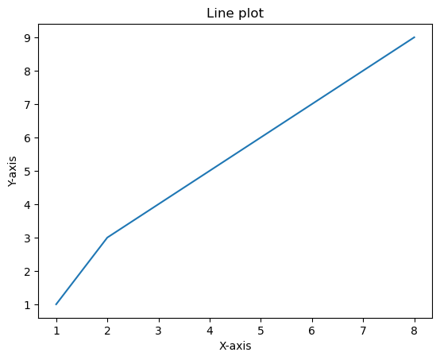

```python
# Line plot
x = [1,2,4,6,8]
y = [1,3,5,7,9]
plt.plot(x,y)
plt.xlabel('X-axis')
plt.ylabel('Y-axis')
plt.title('Line plot');
```

# differnt types of colors

# differnt types of markers

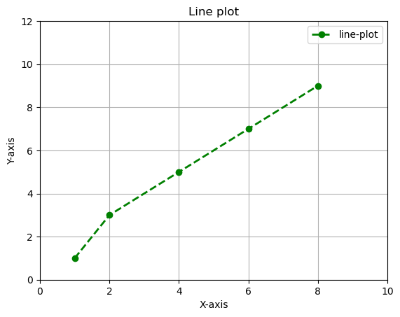

```python
# customized line plot
# different line styles = supported values are '-', '--', '-.', ':', 'None', ' ', '', 'solid', 'dashed', 'dashdot', 'dotted'
plt.plot(x,y,color = 'g',linestyle='--',marker = 'o',label = 'line-plot',linewidth =2,zorder=3);
plt.xlabel('X-axis')
plt.ylabel('Y-axis')
plt.xlim(0,10) # x axis limits
plt.ylim(0,12) # y axis limits
plt.title('Line plot')
plt.grid(True) # to create grids
plt.legend(); # will help to display label on the plot like line-plot in this image
# line width will give the line darkly
```

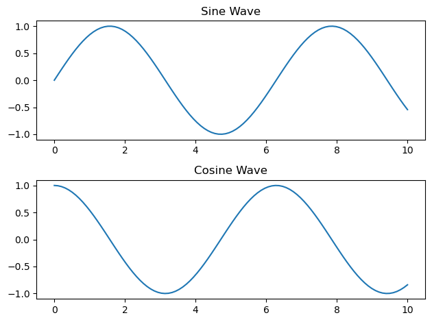

```python
import matplotlib.pyplot as plt
import numpy as np

# Sample data
x = np.linspace(0, 10, 100)
y1 = np.sin(x)
y2 = np.cos(x)

# Create subplots (nrows, ncols)
fig, ax = plt.subplots(2, 1)  # 2 rows, 1 column of subplots

# First subplot (sin plot)
ax[0].plot(x, y1)
ax[0].set_title('Sine Wave')

# Second subplot (cos plot)
ax[1].plot(x, y2)
ax[1].set_title('Cosine Wave')

# Add spacing between plots
plt.tight_layout()

# Display the plot
plt.show()
```

```python
x = np.linspace(0, 10, 100)
print(x) # creates from 0 to 10  , 100 values are created
```

```
[ 0.          0.1010101   0.2020202   0.3030303   0.4040404   0.50505051
  0.60606061  0.70707071  0.80808081  0.90909091  1.01010101  1.11111111
  1.21212121  1.31313131  1.41414141  1.51515152  1.61616162  1.71717172
  1.81818182  1.91919192  2.02020202  2.12121212  2.22222222  2.32323232
  2.42424242  2.52525253  2.62626263  2.72727273  2.82828283  2.92929293
  3.03030303  3.13131313  3.23232323  3.33333333  3.43434343  3.53535354
  3.63636364  3.73737374  3.83838384  3.93939394  4.04040404  4.14141414
  4.24242424  4.34343434  4.44444444  4.54545455  4.64646465  4.74747475
  4.84848485  4.94949495  5.05050505  5.15151515  5.25252525  5.35353535
  5.45454545  5.55555556  5.65656566  5.75757576  5.85858586  5.95959596
  6.06060606  6.16161616  6.26262626  6.36363636  6.46464646  6.56565657
  6.66666667  6.76767677  6.86868687  6.96969697  7.07070707  7.17171717
  7.27272727  7.37373737  7.47474747  7.57575758  7.67676768  7.77777778
  7.87878788  7.97979798  8.08080808  8.18181818  8.28282828  8.38383838
  8.48484848  8.58585859  8.68686869  8.78787879  8.88888889  8.98989899
  9.09090909  9.19191919  9.29292929  9.39393939  9.49494949  9.5959596
  9.6969697   9.7979798   9.8989899  10.        ]
```

```python
y1 = np.sin(x)
print(y1) # for every x value apply sin
```

```
[ 0.          0.10083842  0.20064886  0.2984138   0.39313661  0.48385164
  0.56963411  0.64960951  0.72296256  0.78894546  0.84688556  0.8961922
  0.93636273  0.96698762  0.98775469  0.99845223  0.99897117  0.98930624
  0.96955595  0.93992165  0.90070545  0.85230712  0.79522006  0.73002623
  0.65739025  0.57805259  0.49282204  0.40256749  0.30820902  0.21070855
  0.11106004  0.01027934 -0.09060615 -0.19056796 -0.28858706 -0.38366419
 -0.47483011 -0.56115544 -0.64176014 -0.7158225  -0.7825875  -0.84137452
 -0.89158426 -0.93270486 -0.96431712 -0.98609877 -0.99782778 -0.99938456
 -0.99075324 -0.97202182 -0.94338126 -0.90512352 -0.85763861 -0.80141062
 -0.73701276 -0.66510151 -0.58640998 -0.50174037 -0.41195583 -0.31797166
 -0.22074597 -0.12126992 -0.0205576   0.0803643   0.18046693  0.27872982
  0.37415123  0.46575841  0.55261747  0.63384295  0.7086068   0.77614685
  0.83577457  0.8868821   0.92894843  0.96154471  0.98433866  0.99709789
  0.99969234  0.99209556  0.97438499  0.94674118  0.90944594  0.86287948
  0.8075165   0.74392141  0.6727425   0.59470541  0.51060568  0.42130064
  0.32770071  0.23076008  0.13146699  0.03083368 -0.07011396 -0.17034683
 -0.26884313 -0.36459873 -0.45663749 -0.54402111]
```

## *Types of Plots available in Matplotlib*

The `Matplotlib` library in Python provides a wide range of visualization types to represent data in various ways. Here's a list of common visualizations you can create using `Matplotlib`:

### 1. **Line Plot (`plot`)**

- **Description**: Plots data points connected by lines. Useful for showing trends over time or continuous data.
- **Code**: `plt.plot(x, y)`

### 2. **Scatter Plot (`scatter`)**

- **Description**: Displays data points (markers) on a 2D plane, typically used to show the relationship between two variables.
- **Code**: `plt.scatter(x, y)`

### 3. **Bar Plot (`bar` or `barh`)**

- **Description**: Displays rectangular bars to represent data. The height (or width for horizontal bars) of the bars represents the value.
- **Code**: `plt.bar(x, height)` or `plt.barh(x, width)`

### 4. **Histogram (`hist`)**

- **Description**: Shows the distribution of data by grouping data into bins and displaying the frequency of data points within each bin.
- **Code**: `plt.hist(data, bins=number_of_bins)`

### 5. **Pie Chart (`pie`)**

- **Description**: Divides a circle into proportional segments to represent different categories.
- **Code**: `plt.pie(sizes, labels=categories)`

### 6. **Box Plot (or Box-and-Whisker Plot) (`boxplot`)**

- **Description**: Shows the distribution of data based on five summary statistics: minimum, first quartile (Q1), median, third quartile (Q3), and maximum.
- **Code**: `plt.boxplot(data)`

### 7. **Violin Plot (`violinplot`)**

- **Description**: Similar to a box plot but also shows the probability density of the data at different values, giving a more detailed view of the data distribution.
- **Code**: `plt.violinplot(data)`

### 8. **Area Plot (`fill_between`)**

- **Description**: Displays a filled area under the line, useful for comparing volume over time.
- **Code**: `plt.fill_between(x, y)`

### 9. **Error Bar Plot (`errorbar`)**

- **Description**: Shows error margins in the form of vertical or horizontal error bars around each data point.
- **Code**: `plt.errorbar(x, y, yerr=error_margin)`

### 10. **Heatmap (with `imshow` or `pcolormesh`)**

- **Description**: Represents data in matrix form with color indicating the magnitude of values. Useful for showing correlations, matrices, or grid-based data.
- **Code**: `plt.imshow(data, cmap='viridis')` or `plt.pcolormesh(data)`

### 11. **Contour Plot (`contour` and `contourf`)**

- **Description**: Represents 3D data in two dimensions using contour lines (or filled contours) to show different levels.
- **Code**: `plt.contour(X, Y, Z)` or `plt.contourf(X, Y, Z)`

### 12. **Quiver Plot (`quiver`)**

- **Description**: Displays velocity vectors as arrows, typically used to represent wind flow, currents, or vector fields.
- **Code**: `plt.quiver(X, Y, U, V)`

### 13. **Stem Plot (`stem`)**

- **Description**: A discrete plot where each data point is represented by a vertical line extending from a baseline, ending with a marker.
- **Code**: `plt.stem(x, y)`

### 14. **Polar Plot (`polar`)**

- **Description**: A plot on a polar coordinate system, often used for circular data.
- **Code**: `plt.polar(theta, r)`

### 15. **3D Plot (`plot_surface`, `plot_wireframe`, etc.)**

- **Description**: Used to plot 3D data. Requires importing the `Axes3D` module from `mpl_toolkits.mplot3d`.
- **Code**:
  - Surface Plot: `ax.plot_surface(X, Y, Z)`
  - Wireframe Plot: `ax.plot_wireframe(X, Y, Z)`
  - Scatter Plot in 3D: `ax.scatter(X, Y, Z)`

### 16. **Stacked Bar Plot**

- **Description**: A bar plot where bars are stacked on top of each other to show cumulative data.
- **Code**: `plt.bar(x, height1, bottom=height2)`

### 17. **Step Plot (`step`)**

- **Description**: A line plot that uses steps to connect data points, useful for representing discrete changes.
- **Code**: `plt.step(x, y)`

### 18. **Hexbin Plot (`hexbin`)**

- **Description**: A 2D histogram plot where the data is divided into hexagonal bins, representing density.
- **Code**: `plt.hexbin(x, y, gridsize=number_of_bins)`

### 19. **Event Plot (`eventplot`)**

- **Description**: Visualizes events on a timeline, typically used for representing discrete occurrences or spikes.
- **Code**: `plt.eventplot(data)`

### 20. **Logarithmic Plot (`semilogx`, `semilogy`, `loglog`)**

- **Description**: Plots where one or both axes are logarithmic.
- **Code**:
  - `plt.semilogx(x, y)` (log scale on x-axis)
  - `plt.semilogy(x, y)` (log scale on y-axis)
  - `plt.loglog(x, y)` (log scale on both axes)

### 21. **Density Plot (using `Seaborn` on top of `Matplotlib`)**

- **Description**: A smoothed representation of the distribution of data.
- **Code**: `sns.kdeplot(data)`

These are the most common types of visualizations available in `Matplotlib`. Each one serves different purposes depending on the data and the insights you want to highlight. You can customize them further with colors, labels, titles, annotations, and more.

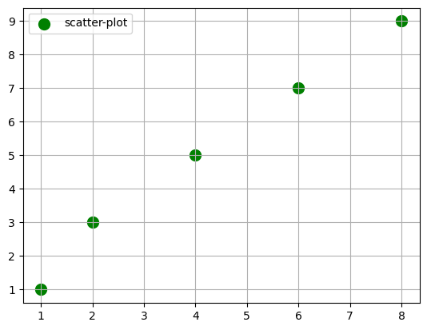

```python
# scatter
x = [1,2,4,6,8]
y = [1,3,5,7,9]
plt.scatter(x,y,marker = 'o',linewidths=5,c='g',label= 'scatter-plot');
plt.grid(True)
plt.legend()
```

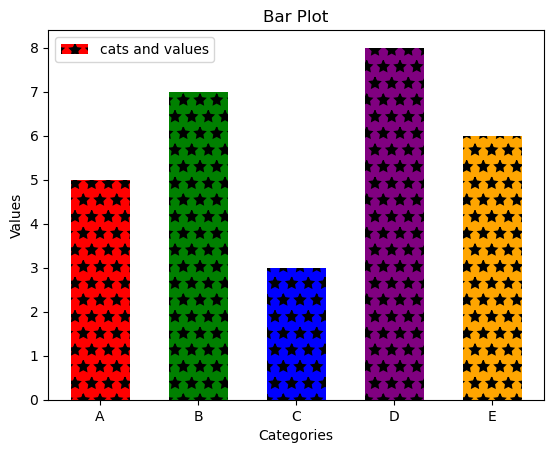

```python
###Bar Plot
categories=['A','B','C','D','E']
values=[5,7,3,8,6]
#hatch: {'/', '\\', '|', '-', '+', 'x', 'o', 'O', '.', '*'}
#linestyle or ls: {'-', '--', '-.', ':', '', (offset, on-off-seq), ...}
##create a bar plot
plt.bar(categories,values,color=['red', 'green', 'blue','purple','orange'],width = 0.6,hatch='*',label='cats and values')

plt.xlabel('Categories')
plt.ylabel('Values')
plt.title('Bar Plot')
plt.legend()
#plt.grid(True)
plt.show()
```

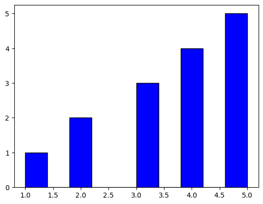

```python
# histogram
# Sample data
data = [1, 2, 2, 3, 3, 3, 4, 4, 4, 4, 5, 5, 5, 5, 5]

##create a histogram
plt.hist(data,bins=10,color='b',edgecolor='black');
#plt.grid(True)
```

#### In a histogram, bins=10 means that the data will be divided into 10 equal-width intervals (or bins) along the x-axis.

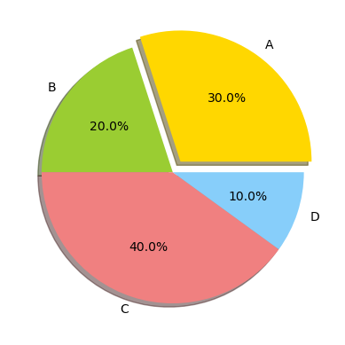

```python
### pie chart

labels=['A','B','C','D']
sizes=[30,20,40,10]
colors=['gold','yellowgreen','lightcoral','lightskyblue']
explode=(0.1,0,0,0) ##move out the 1st slice

##create apie chart
plt.pie(sizes,explode=explode,labels=labels,colors=colors,autopct="%1.1f%%",shadow=True);
```

```python
print('---'*100)
```

[output not shown]

In a **Matplotlib pie chart**, the `plt.pie()` function has several parameters that allow you to customize the chart’s appearance and behavior. Here's a detailed explanation of each parameter:

### 1. **`x`** (Required)

- **Description**: The input data representing the sizes of the pie slices. This is typically a list, array, or similar structure that holds numerical values (e.g., `[30, 20, 50]`).
- **Example**: `x=[30, 20, 50]`

### 2. **`labels`**

- **Description**: A list of strings representing the labels corresponding to each slice. These labels are displayed alongside each wedge.
- **Default**: `None`
- **Example**: `labels=['A', 'B', 'C']`

### 3. **`colors`**

- **Description**: A sequence of colors to be used for each slice of the pie. You can use a list of color names, hexadecimal color codes, or RGB tuples.
- **Default**: Uses a default color cycle.
- **Example**: `colors=['#ff9999', '#66b3ff', '#99ff99']`

### 4. **`autopct`**

- **Description**: Controls how percentages are displayed on the slices. It accepts a string or a function.
  - **String format**: Example: `'%1.1f%%'` (to display percentages with 1 decimal place).
  - **Function**: Example: A lambda function to conditionally display percentages.
- **Default**: `None` (percentages are not displayed).
- **Example**: `autopct='%1.1f%%'` or `autopct=lambda p: '{:.0f}%'.format(p)`

### 5. **`explode`**

- **Description**: A sequence of values to offset individual slices from the center. Each value represents how far the corresponding slice is "exploded" or pushed away from the center.
- **Default**: `None`
- **Example**: `explode=[0, 0.1, 0]` (the second slice will be "exploded" outward by 0.1 units).

### 6. **`startangle`**

- **Description**: The starting angle of the pie chart, measured counterclockwise from the x-axis. Useful for rotating the pie chart to a specific orientation.
- **Default**: `0` degrees.
- **Example**: `startangle=90` (starts at the top of the circle).

### 7. **`shadow`**

- **Description**: Adds a shadow behind the pie chart, giving it a 3D effect.
- **Default**: `False`
- **Example**: `shadow=True`

### 8. **`radius`**

- **Description**: The radius of the pie chart. Controls the overall size of the pie.
- **Default**: `1.0` (default unit circle).
- **Example**: `radius=1.5` (increases the size of the pie).

### 9. **`counterclock`**

- **Description**: Determines the direction in which the slices are plotted. If `True`, slices are plotted counterclockwise; if `False`, they are plotted clockwise.
- **Default**: `True`
- **Example**: `counterclock=False` (plots in a clockwise direction).

### 10. **`wedgeprops`**

- **Description**: A dictionary to customize the appearance of the pie slices (wedges). You can specify properties like edge color, line width, etc.
- **Default**: `None`
- **Example**: `wedgeprops={'edgecolor': 'black', 'linewidth': 2}` (sets black edges and thicker lines).

### 11. **`textprops`**

- **Description**: A dictionary to customize the appearance of text labels. You can set properties like font size, color, etc.
- **Default**: `None`
- **Example**: `textprops={'fontsize': 14, 'color': 'black'}` (sets the font size and color of the text labels).

### 12. **`center`**

- **Description**: Specifies the center of the pie chart in (x, y) coordinates.
- **Default**: `(0, 0)` (the center of the plot area).
- **Example**: `center=(1, 1)`

### 13. **`frame`**

- **Description**: When `True`, draws a frame around the chart.
- **Default**: `False`
- **Example**: `frame=True`

### 14. **`pctdistance`**

- **Description**: The ratio between the center of the pie and the location of the percentage text. It controls how far the percentages are placed from the center.
- **Default**: `0.6`
- **Example**: `pctdistance=0.8` (moves the percentage text further away from the center).

### 15. **`labeldistance`**

- **Description**: The radial distance at which the labels are drawn. The distance is measured as a fraction of the pie radius.
- **Default**: `1.1`
- **Example**: `labeldistance=1.2` (moves labels further away from the pie chart).

### 16. **`normalize`**

- **Description**: Normalizes the values of the pie chart if the sum of the values is not equal to 1.
- **Default**: `None`
- **Example**: `normalize=True`

### 17. **`colors`**

- **Description**: A sequence of colors for each wedge in the pie chart. It can be a list of colors, hex codes, or color names.
- **Default**: `None` (uses the default Matplotlib color cycle).
- **Example**: `colors=['#ff9999', '#66b3ff', '#99ff99']`

### Example Pie Chart with Multiple Parameters:

```
import matplotlib.pyplot as plt

# Data for the pie chart
sizes = [30, 20, 50]
labels = ['A', 'B', 'C']
colors = ['#ff9999', '#66b3ff', '#99ff99']
explode = [0, 0.1, 0]  # Explode the second slice

# Create pie chart
plt.pie(
    sizes,
    labels=labels,
    colors=colors,
    explode=explode,
    autopct='%1.1f%%',
    startangle=90,
    shadow=True,
    wedgeprops={'edgecolor': 'black'},
    textprops={'fontsize': 12}
)

plt.title('Customized Pie Chart')
plt.show()
```

This example demonstrates how to combine several parameters (`labels`, `colors`, `explode`, `autopct`, `startangle`, `shadow`, etc.) to create a fully customized pie chart.

```python
#data.plot(kind = 'bar',color='green')
# we use kind to give the name of plot
```

#### october 18 2024

## 4.Seaborn

```python
import seaborn as sns
import matplotlib.pyplot as plt
```

```python
### Basic Plotting With Seaborn
tips=sns.load_dataset('tips')
tips
```

|  | total_bill | tip | sex | smoker | day | time | size |
| --- | --- | --- | --- | --- | --- | --- | --- |
| 0 | 16.99 | 1.01 | Female | No | Sun | Dinner | 2 |
| 1 | 10.34 | 1.66 | Male | No | Sun | Dinner | 3 |
| 2 | 21.01 | 3.50 | Male | No | Sun | Dinner | 3 |
| 3 | 23.68 | 3.31 | Male | No | Sun | Dinner | 2 |
| 4 | 24.59 | 3.61 | Female | No | Sun | Dinner | 4 |
| ... | ... | ... | ... | ... | ... | ... | ... |
| 239 | 29.03 | 5.92 | Male | No | Sat | Dinner | 3 |
| 240 | 27.18 | 2.00 | Female | Yes | Sat | Dinner | 2 |
| 241 | 22.67 | 2.00 | Male | Yes | Sat | Dinner | 2 |
| 242 | 17.82 | 1.75 | Male | No | Sat | Dinner | 2 |
| 243 | 18.78 | 3.00 | Female | No | Thur | Dinner | 2 |

244 rows × 7 columns

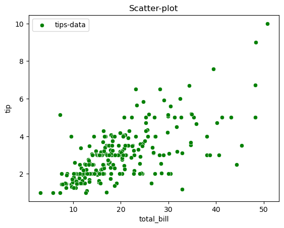

```python
sns.scatterplot(x='total_bill',y = 'tip',c='g',data=tips,label='tips-data')
plt.title('Scatter-plot')
plt.legend();
```

```python
tips['total_bill'].mean()
```

```
19.78594262295082
```

### Types of plots available in Seaborn

Seaborn offers a wide variety of plots to help with statistical data visualization. Here are some of the common plot types in Seaborn:

### 1. **Relational Plots**

- **scatterplot()**: Displays relationships between two variables as points.
- **lineplot()**: Shows relationships between continuous data with lines.

### 2. **Categorical Plots**

- **stripplot()**: A scatter plot that displays individual data points along a categorical axis.
- **swarmplot()**: Similar to `stripplot()`, but the points are adjusted to avoid overlap, making it easier to see the distribution of points.
- **boxplot()**: Displays the distribution of data based on five summary statistics: minimum, first quartile, median, third quartile, and maximum.
- **violinplot()**: Combines a boxplot with a KDE (Kernel Density Estimate) plot to show data distribution.
- **barplot()**: Shows the distribution of data with bars, useful for comparing categorical data with aggregate statistics.
- **pointplot()**: Displays point estimates and confidence intervals for different categories.

### 3. **Distribution Plots**

- **histplot()**: Displays the distribution of a dataset using a histogram.
- **kdeplot()**: Shows the probability density function of a continuous variable using a smooth curve.
- **distplot()** (Deprecated): Combines a histogram and a KDE plot.
- **rugplot()**: Shows individual data points along the x-axis, often used with other plots.
- **ecdfplot()**: Shows the empirical cumulative distribution function.

### 4. **Matrix Plots**

- **heatmap()**: Displays data in a matrix format, useful for showing correlations or frequencies in a grid.
- **clustermap()**: Similar to a heatmap but with hierarchical clustering to organize rows and columns.

### 5. **Pairwise Plots**

- **pairplot()**: Creates a matrix of scatterplots or KDE plots for pairwise relationships between variables in a dataset.